# Client Report - The War with Star Wars

- Show All Code
- Hide All Code

Course DS 250

Author

Rebecca Roeth

## Elevator pitch

While the dataset is fun, there is very few pieces of information that can actually be used for the final question 4 where I will be creating a ML model to predict if someone makes $50k or more. Additionally, the category I use “Household Income” is a vague target for what I want to find out. However, by making the dataset more readable, I was able to figure out what was useable and other facinating information about the dataset.

**Read and format project data**

```python
# Learn morea about Code Cells: https://quarto.org/docs/reference/cells/cells-jupyter.html

# Include and execute your code here
url = "https://raw.githubusercontent.com/fivethirtyeight/data/master/star-wars-survey/StarWars.csv"
data = pd.read_csv(url, encoding='unicode_escape')
```

**Highlight the Questions and Tasks**

## Clean Up

**Shorten the column names and clean them up for easier use with pandas. Provide a table or list that exemplifies how you fixed the names.**

```python
data.rename(columns = {
    'Have you seen any of the 6 films in the Star Wars franchise?': 'Seen_SW',
    'Do you consider yourself to be a fan of the Star Wars film franchise?': 'Fan_of_SW',
    'Which character shot first?':'shot_first',
    'Are you familiar with the Expanded Universe?':'familair_EU',
    'Do you consider yourself to be a fan of the Expanded Universe?':'fan_EU',
    'Do you consider yourself to be a fan of the Star Trek franchise?':'ST_fan',
    'Household Income':'Income',

    #Context clues said these are the Star wars movies of the original and newest trilogies
    'Which of the following Star Wars films have you seen? Please select all that apply.':'SW1',
    'Unnamed: 4': 'SW2',
    'Unnamed: 5': 'SW3',
    'Unnamed: 6': 'SW4',
    'Unnamed: 7': 'SW5',
    'Unnamed: 8': 'SW6',

    'Please rank the Star Wars films in order of preference with 1 being your favorite film in the franchise and 6 being your least favorite film.':'SW1_ranked',
    'Unnamed: 10': 'SW2_ranked',
    'Unnamed: 11': 'SW3_ranked',
    'Unnamed: 12': 'SW4_ranked',
    'Unnamed: 13': 'SW5_ranked',
    'Unnamed: 14': 'SW6_ranked',

#Jar Jar Binks,Padme Amidala,Yoda,

    'Please state whether you view the following characters favorably, unfavorably, or are unfamiliar with him/her.': 'Han_Solo',
    'Unnamed: 16': 'Luke_Skywalker',
    'Unnamed: 17': 'Princes_Leia',
    'Unnamed: 18': 'Anakin',
    'Unnamed: 19': 'Obi Wan',
    'Unnamed: 20': 'Palpatine',
    'Unnamed: 21': 'Darth_Vadar',
    'Unnamed: 22': 'Lando_Calrissian',
    'Unnamed: 23': 'Boba_Fett',
    'Unnamed: 24': 'C-3PO',
    'Unnamed: 25': 'R2_D2',
    'Unnamed: 26': 'Jar_Jar_Binks',
    'Unnamed: 27': 'Padme_Amidala',
    'Unnamed: 28': 'Yoda'

}, inplace = True)

print(data.info())
```

```
<class 'pandas.core.frame.DataFrame'>
RangeIndex: 1187 entries, 0 to 1186
Data columns (total 38 columns):
 #   Column                                                            Non-Null Count  Dtype
---  ------                                                            --------------  -----
 0   RespondentID                                                      1186 non-null   float64
 1   Seen_SW                                                           1187 non-null   object
 2   Fan_of_SW                                                         837 non-null    object
 3   SW1                                                               674 non-null    object
 4   SW2                                                               572 non-null    object
 5   SW3                                                               551 non-null    object
 6   SW4                                                               608 non-null    object
 7   SW5                                                               759 non-null    object
 8   SW6                                                               739 non-null    object
 9   SW1_ranked                                                        836 non-null    object
```

[output cut: 31 more lines]

## Formating

**Clean and format the data so that it can be used in a machine learning model. As you format the data, you should complete each item listed below**

*Part A*

**Filter the dataset to respondents that have seen at least one film.**

```python
data = data.query('Seen_SW == "Yes"')
print(data.filter(["Seen_SW"]).head())
```

```
  Seen_SW
1     Yes
3     Yes
4     Yes
5     Yes
6     Yes
```

*Part B*

**Create a new column that converts the age ranges to a single number. Drop the age range categorical column.**

```python
def split_age(i):
    age_list = str(i.Age).split("-")
    if age_list[0] == "> 60":
        return 61
    elif age_list[0] == "NaN":
        return 0
    return float(age_list[0])

data['Age'] = data['Age'].fillna(0)
data["age_range"] = data.apply(split_age, axis=1)
del data['Age']

print(data.filter(["age_range"]))
```

```
      age_range
1          18.0
3          18.0
4          18.0
5          18.0
6          18.0
...         ...
1181       45.0
1182       18.0
1183       30.0
1185       45.0
1186       61.0

[936 rows x 1 columns]
```

*Part C*

**Create a new column that converts the education groupings to a single number. Drop the school categorical column**

```python
def split_education(i):
    i = i.Education
    if i == "High school degree":
        return 1.0
    elif i == "Some college or Associate degree":
        return 2.0
    elif i == "Bachelor degree":
        return 3.0
    elif i == "Graduate degree":
        return 4.0
data["education"] = data.apply(split_education, axis=1)
data['education'] = data['education'].fillna(0)
del data['Education']
print(data.filter(["education"]))
```

```
      education
1           1.0
3           1.0
4           2.0
5           2.0
6           3.0
...         ...
1181        2.0
1182        2.0
1183        3.0
1185        2.0
1186        4.0

[936 rows x 1 columns]
```

*Part D*

**Create a new column that converts the income ranges to a single number. Drop the income range categorical column.**

```python
def split_income(i):
    income_list = str(i.Income).split(" - ")
    if income_list[0] == "$0":
        return 1
    elif income_list[0] == "$25,000":
        return 2
    elif income_list[0] == "$50,000":
        return 4
    elif income_list[0] == "$100,000":
        return 8
    elif income_list[0] == "$150,000+":
        return 12
    else: # NaN
        return 0

data["Income_range"] = data.apply(split_income, axis=1)
del data['Income']
print(data.filter(["Income_range"]))
```

```
      Income_range
1                0
3                1
4                8
5                8
6                2
...            ...
1181             1
1182             1
1183             4
1185             8
1186             4

[936 rows x 1 columns]
```

*Part E*

**Create your target (also known as “y” or “label”) column based on the new income range column.**

```python
def label_function(i):
    if i.Income_range >= 4:
        return True
    else:
        return False
data['y'] = data.apply(label_function, axis=1)
```

*Part F*

**One-hot encode all remaining categorical columns.**

```python
from sklearn.preprocessing import OneHotEncoder
category_list = [
  'SW1','SW2','SW3','SW4','SW5','SW6',#'SW1_ranked','SW2_ranked','SW3_ranked','SW4_ranked','SW5_ranked','SW6_ranked',

  'Luke_Skywalker','Princes_Leia','Anakin','Obi Wan','Palpatine','Darth_Vadar','Lando_Calrissian',
  'Boba_Fett','C-3PO','R2_D2','Jar_Jar_Binks','Padme_Amidala','Yoda',

  'Seen_SW','Fan_of_SW','familair_EU','ST_fan',
  'Gender','Location (Census Region)',
]
enc = OneHotEncoder()
enc_data = 0
for i in category_list:
    data[(i)] = data[(i)].astype('category').cat.codes

    enc_data += pd.DataFrame(enc.fit_transform(data[[i]]).toarray())

data = data.join(enc_data)
print(data.info())
```

```
<class 'pandas.core.frame.DataFrame'>
Index: 936 entries, 1 to 1186
Data columns (total 41 columns):
 #   Column                                                            Non-Null Count  Dtype
---  ------                                                            --------------  -----
 0   RespondentID                                                      936 non-null    float64
 1   Seen_SW                                                           936 non-null    int8
 2   Fan_of_SW                                                         936 non-null    int8
 3   SW1                                                               936 non-null    int8
 4   SW2                                                               936 non-null    int8
 5   SW3                                                               936 non-null    int8
 6   SW4                                                               936 non-null    int8
 7   SW5                                                               936 non-null    int8
 8   SW6                                                               936 non-null    int8
 9   SW1_ranked                                                        835 non-null    object
```

[output cut: 34 more lines]

## Graphs and articles

**Validate that the data provided on GitHub lines up with the article by recreating 2 of the visuals from the article.**

*https://fivethirtyeight.com/features/americas-favorite-star-wars-movies-and-least-favorite-characters/*

```python
movies_ranked = ['SW1_ranked','SW2_ranked','SW3_ranked','SW4_ranked','SW5_ranked','SW6_ranked']
seen_all = data.query('SW1 == 0 and SW2 == 0 and SW3 == 0 and SW4 == 0 and SW5 == 0 and SW6 == 0')
#print(seen_all.filter(['SW1_ranked','SW2_ranked','SW3_ranked','SW4_ranked','SW5_ranked','SW6_ranked']).head())

def SW_Movie_Seen(i):
# Which of the following Star Wars films have you seen?
    if i.SW1_ranked == "1":
        return "SW1"
    elif i.SW2_ranked == "1":
        return "SW2"
    elif i.SW3_ranked == "1":
        return "SW3"
    elif i.SW4_ranked == "1":
        return "SW4"
    elif i.SW5_ranked == "1":
        return "SW5"
    elif i.SW6_ranked == "1":
        return 'SW6'

seen_all["SW_ranked"] = seen_all.apply(SW_Movie_Seen, axis=1)
#print(New_df.filter(["SW_ranked"]))

chart = px.histogram(seen_all,
    y = "SW_ranked",
    category_orders=dict(SW_ranked=['SW1','SW2','SW3','SW4','SW5','SW6']),
    title = "Which 'Star Wars' Movies Have You Seen?"
    )
chart.show()

# Who shot first?
chart2 = px.histogram(data,
    y = "shot_first",
    title = "Who Shot First?"
)
chart2.show()
```

[interactive chart not shown]

## QUESTION|TASK 4

**Build a machine learning model that predicts whether a person makes more than $50k. Describe your model and report the accuracy.**

```python
from sklearn.model_selection import train_test_split
from sklearn.naive_bayes import BernoulliNB, CategoricalNB, ComplementNB, GaussianNB, MultinomialNB
from sklearn.metrics import accuracy_score

from sklearn import metrics
import matplotlib.pyplot as plt
```

I found through running graphs the columns that would make the best features. However, because I struggled with the one-hot encoding and the Star Trek fan column was unable to work.

```
      age_range  education
173        18.0        3.0
1077       45.0        3.0
140        61.0        2.0
1140        0.0        0.0
846         0.0        0.0
...         ...        ...
835        61.0        2.0
688        18.0        3.0
1162        0.0        0.0
339        30.0        2.0
782        61.0        3.0

[281 rows x 2 columns]
0.6156583629893239
0.6156583629893239
```

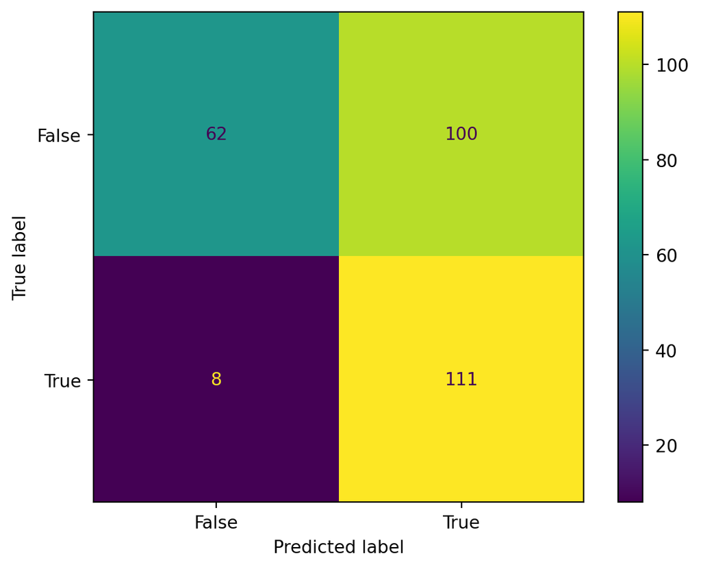

```python
features = data.filter([
    'age_range', 'education' #'SW6_ranked', 'Jar_Jar_Binks, ST_fan
])
targets = data.filter(['y'])

train_data, test_data, train_targets, test_targets = train_test_split(features, targets, test_size=0.3)
print(test_data)
#BernoulliNB, CategoricalNB, ComplementNB, GaussianNB, MultinomialNB
classifier = CategoricalNB()
classifier.fit(train_data, train_targets)

targets_predicted = classifier.predict(test_data)
accuracy = accuracy_score(test_targets, targets_predicted)
print(accuracy)

print(classifier.score(test_data, test_targets))

confusion_matrix = metrics.confusion_matrix(test_targets, targets_predicted)
cm_display = metrics.ConfusionMatrixDisplay(confusion_matrix = confusion_matrix, display_labels = [False, True])
cm_display.plot()
plt.show()
```